# Bellabeat Data Analysis

Engr. Airro King T. Robles

2025-09-21

## Scenario

I am a junior data analyst working on the marketing analyst team at Bellabeat, a high-tech manufacturer of health-focused products for women. Bellabeat is a successful small company, but they have the potential to become a larger player in the global smart device market. Urška Sršen, cofounder and Chief Creative Officer of Bellabeat, believes that analyzing smart device fitness data could help unlock new growth opporunities for the company. I have been asked to focus on one of Bellabeat’s products and analyze smart device data to gain insight into how consumers are using their smart devices. The insights I discover will then help guide marketing strategy for the company. I will present the analysis to the Bellabeat executive team along with high-level recommendations for Bellabeat’s marketing strategy.

## Business Tasks

Sršen asks to analyze smart device usage data in order to gain insight into how consumers use non-Bellabeat smart devices. She then wants to select one Bellabeat product to apply these insights to in the presentation. These questions will guide the analysis:  
1. What are some trends in smart device usage?  
2. How could these trends apply to Bellabeat customers?  
3. How could these trends help influence Bellabeat marketing strategy?

A repo shall be produced with the following deliverables:  
1. A clear summary of the business task  
2. A description of all data sources used  
3. Documentation of any cleaning or manipulation of data  
4. A summary of analysis  
5. Supporting visualizations and key findings  
6. Top high-level content recommendations based on your analysis

## Data Set Used

- FitBit Fitness Tracker Data (CC0: Public Domain, dataset made available through Mobius): This Kaggle data set contains personal fitness tracker from thirty Fitbit users. Thirty eligible Fitbit users consented to the submission of personal tracker data, including minute-level output for physical activity, heart rate, and sleep monitoring. It includes information about daily activity, steps, and heart rate that can be used to explore users’ habits.

#### Loading the Required Packages

```r
library(tidyverse)
```

```r
library(lubridate)
library(ggplot2)
library(readr)
```

#### Importing the Data Set

```r
steps_minute_df <- read_csv("C:/Users/guest_123/Downloads/mturkfitbit_export_3.12.16-4.11.16/Fitabase Data 3.12.16-4.11.16/minuteStepsNarrow_merged.csv")
weight_df <- read_csv("C:/Users/guest_123/Downloads/mturkfitbit_export_3.12.16-4.11.16/Fitabase Data 3.12.16-4.11.16/weightLogInfo_merged.csv")
heartrate_df <- read_csv("C:/Users/guest_123/Downloads/mturkfitbit_export_3.12.16-4.11.16/Fitabase Data 3.12.16-4.11.16/heartrate_seconds_merged.csv")
calories_hourly_df <- read_csv("C:/Users/guest_123/Downloads/mturkfitbit_export_3.12.16-4.11.16/Fitabase Data 3.12.16-4.11.16/hourlyCalories_merged.csv")
intensities_hourly_df <- read_csv("C:/Users/guest_123/Downloads/mturkfitbit_export_3.12.16-4.11.16/Fitabase Data 3.12.16-4.11.16/hourlyIntensities_merged.csv")
steps_hourly_df <- read_csv("C:/Users/guest_123/Downloads/mturkfitbit_export_3.12.16-4.11.16/Fitabase Data 3.12.16-4.11.16/hourlySteps_merged.csv")
calories_minute_df <- read_csv("C:/Users/guest_123/Downloads/mturkfitbit_export_3.12.16-4.11.16/Fitabase Data 3.12.16-4.11.16/minuteCaloriesNarrow_merged.csv")
intensities_minute_df <- read_csv("C:/Users/guest_123/Downloads/mturkfitbit_export_3.12.16-4.11.16/Fitabase Data 3.12.16-4.11.16/minuteIntensitiesNarrow_merged.csv")
met_minute_df <- read_csv("C:/Users/guest_123/Downloads/mturkfitbit_export_3.12.16-4.11.16/Fitabase Data 3.12.16-4.11.16/minuteMETsNarrow_merged.csv")
sleep_minute_df <- read_csv("C:/Users/guest_123/Downloads/mturkfitbit_export_3.12.16-4.11.16/Fitabase Data 3.12.16-4.11.16/minuteSleep_merged.csv")
daily_activity_df <- read_csv("C:/Users/guest_123/Downloads/mturkfitbit_export_3.12.16-4.11.16/Fitabase Data 3.12.16-4.11.16/dailyActivity_merged.csv")
daily_activity_df$ActivityDate <- mdy(daily_activity_df$ActivityDate)
head(daily_activity_df)
```

```
## # A tibble: 6 × 15
##           Id ActivityDate TotalSteps TotalDistance TrackerDistance
##        <dbl> <date>            <dbl>         <dbl>           <dbl>
## 1 1503960366 2016-03-25        11004          7.11            7.11
## 2 1503960366 2016-03-26        17609         11.6            11.6
## 3 1503960366 2016-03-27        12736          8.53            8.53
## 4 1503960366 2016-03-28        13231          8.93            8.93
## 5 1503960366 2016-03-29        12041          7.85            7.85
## 6 1503960366 2016-03-30        10970          7.16            7.16
## # ℹ 10 more variables: LoggedActivitiesDistance <dbl>,
## #   VeryActiveDistance <dbl>, ModeratelyActiveDistance <dbl>,
## #   LightActiveDistance <dbl>, SedentaryActiveDistance <dbl>,
## #   VeryActiveMinutes <dbl>, FairlyActiveMinutes <dbl>,
## #   LightlyActiveMinutes <dbl>, SedentaryMinutes <dbl>, Calories <dbl>
```

```r
head(intensities_hourly_df)
```

```
## # A tibble: 6 × 4
##           Id ActivityHour          TotalIntensity AverageIntensity
##        <dbl> <chr>                          <dbl>            <dbl>
## 1 1503960366 3/12/2016 12:00:00 AM              0                0
## 2 1503960366 3/12/2016 1:00:00 AM               0                0
## 3 1503960366 3/12/2016 2:00:00 AM               0                0
## 4 1503960366 3/12/2016 3:00:00 AM               0                0
## 5 1503960366 3/12/2016 4:00:00 AM               0                0
## 6 1503960366 3/12/2016 5:00:00 AM               0                0
```

```r
head(daily_activity_df)
```

```
## # A tibble: 6 × 15
##           Id ActivityDate TotalSteps TotalDistance TrackerDistance
##        <dbl> <date>            <dbl>         <dbl>           <dbl>
## 1 1503960366 2016-03-25        11004          7.11            7.11
## 2 1503960366 2016-03-26        17609         11.6            11.6
## 3 1503960366 2016-03-27        12736          8.53            8.53
## 4 1503960366 2016-03-28        13231          8.93            8.93
## 5 1503960366 2016-03-29        12041          7.85            7.85
## 6 1503960366 2016-03-30        10970          7.16            7.16
## # ℹ 10 more variables: LoggedActivitiesDistance <dbl>,
## #   VeryActiveDistance <dbl>, ModeratelyActiveDistance <dbl>,
## #   LightActiveDistance <dbl>, SedentaryActiveDistance <dbl>,
## #   VeryActiveMinutes <dbl>, FairlyActiveMinutes <dbl>,
## #   LightlyActiveMinutes <dbl>, SedentaryMinutes <dbl>, Calories <dbl>
```

```r
head(calories_hourly_df)
```

```
## # A tibble: 6 × 3
##           Id ActivityHour          Calories
##        <dbl> <chr>                    <dbl>
## 1 1503960366 3/12/2016 12:00:00 AM       48
## 2 1503960366 3/12/2016 1:00:00 AM        48
## 3 1503960366 3/12/2016 2:00:00 AM        48
## 4 1503960366 3/12/2016 3:00:00 AM        48
## 5 1503960366 3/12/2016 4:00:00 AM        48
## 6 1503960366 3/12/2016 5:00:00 AM        48
```

```r
# Convert dates
daily_activity_df$ActivityDate <- as.Date(daily_activity_df$ActivityDate,
                                          format = "%m/%d/%Y")

calories_hourly_df$ActivityHour <- as.POSIXct(
  calories_hourly_df$ActivityHour,
  format = "%m/%d/%Y %I:%M:%S %p"
)

steps_hourly_df$ActivityHour <- as.POSIXct(
  steps_hourly_df$ActivityHour,
  format = "%m/%d/%Y %I:%M:%S %p"
)

intensities_hourly_df$ActivityHour <- as.POSIXct(
  intensities_hourly_df$ActivityHour,
  format = "%m/%d/%Y %I:%M:%S %p"
)

heartrate_df$Time <- as.POSIXct(
  heartrate_df$Time,
  format = "%m/%d/%Y %I:%M:%S %p"
)

weight_df$Date <- as.POSIXct(
  weight_df$Date,
  format = "%m/%d/%Y %I:%M:%S %p"
)


# Aggregate minute sleep into daily totals
sleep_daily <- sleep_minute_df %>%
  mutate(Date = mdy_hms(date)) %>%
  group_by(Id, Date = as_date(Date)) %>%
  summarise(totalSleepMins = sum(value), .groups = "drop")

# Aggregate steps hourly
steps_hourly_df <- steps_hourly_df %>%
  group_by(Id, ActivityHour) %>%
  summarise(StepTotal = sum(StepTotal), .groups = "drop")

# Aggregate calories hourly
calories_hourly_df <- calories_hourly_df %>%
  group_by(Id, ActivityHour) %>%
  summarise(Calories = sum(Calories), .groups = "drop")

# Aggregate intensities hourly
intensities_hourly_df <- intensities_hourly_df %>%
  group_by(Id, ActivityHour) %>%
  summarise(TotalIntensity = sum(TotalIntensity),
            AverageIntensity = mean(AverageIntensity), .groups = "drop")

# Merge daily activity + sleep
activity_sleep <- daily_activity_df %>%
  left_join(sleep_daily, by = c("Id" = "Id", "ActivityDate" = "Date"))

# Merge hourly steps + calories + intensities
hourly_df <- steps_hourly_df %>%
  left_join(calories_hourly_df, by = c("Id", "ActivityHour")) %>%
  left_join(intensities_hourly_df, by = c("Id", "ActivityHour"))
```

## Data Visualizations

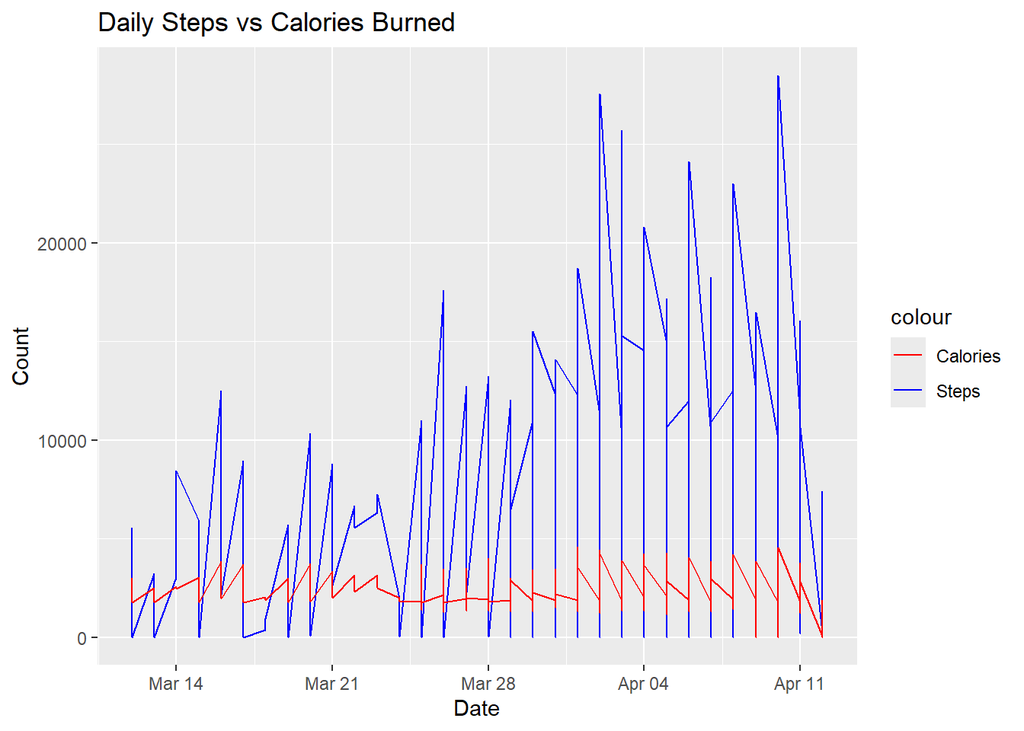

```r
# Daily Trends: Steps vs Calories
ggplot(daily_activity_df, aes(x = ActivityDate)) +
  geom_line(aes(y = TotalSteps, color = "Steps")) +
  geom_line(aes(y = Calories, color = "Calories")) +
  labs(title = "Daily Steps vs Calories Burned",
       x = "Date", y = "Count") +
  scale_color_manual(values = c("Steps" = "blue", "Calories" = "red"))
```

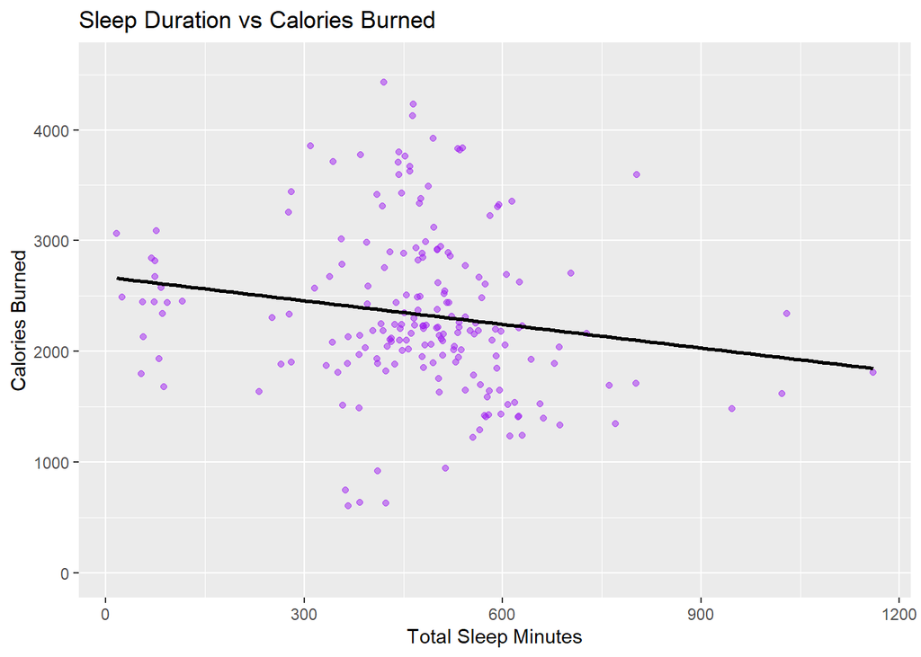

```r
# Sleep vs Activity
ggplot(activity_sleep, aes(x = totalSleepMins, y = Calories)) +
  geom_point(alpha = 0.5, color = "purple") +
  geom_smooth(method = "lm", se = FALSE, color = "black") +
  labs(title = "Sleep Duration vs Calories Burned",
       x = "Total Sleep Minutes", y = "Calories Burned")
```

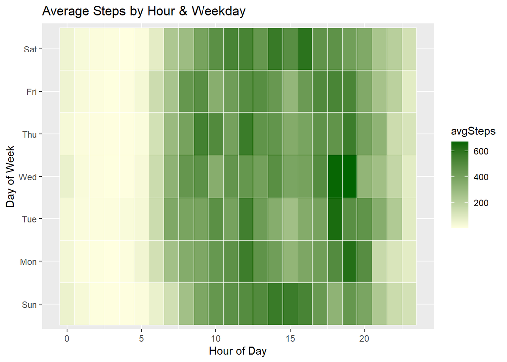

```r
# Hourly Heatmap (Steps)
hourly_df %>%
  mutate(hour = hour(ActivityHour),
         weekday = wday(ActivityHour, label = TRUE)) %>%
  group_by(hour, weekday) %>%
  summarise(avgSteps = mean(StepTotal), .groups = "drop") %>%
  ggplot(aes(x = hour, y = weekday, fill = avgSteps)) +
  geom_tile(color = "white") +
  scale_fill_gradient(low = "lightyellow", high = "darkgreen") +
  labs(title = "Average Steps by Hour & Weekday",
       x = "Hour of Day", y = "Day of Week")
```

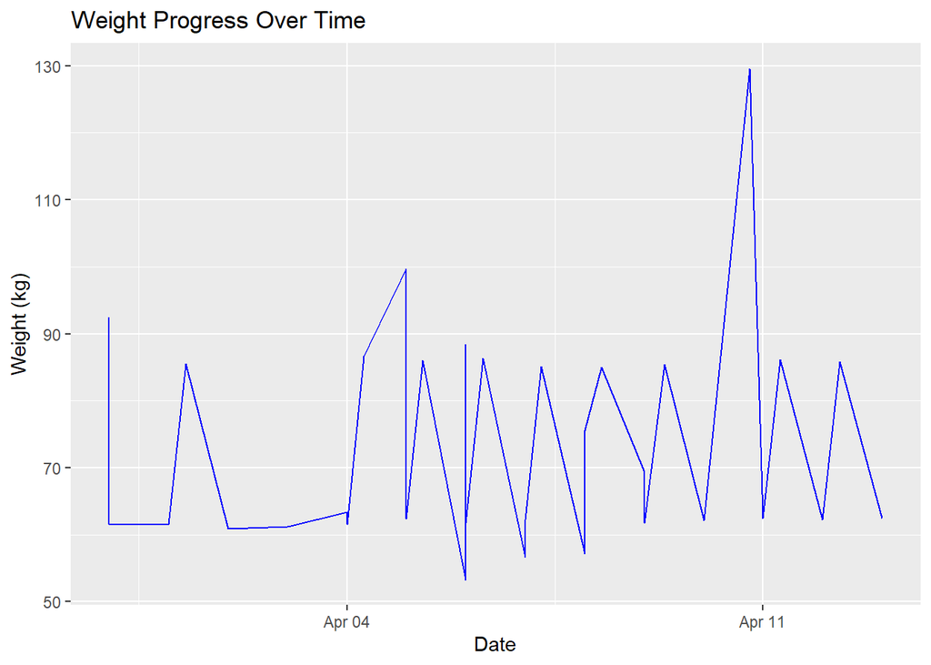

```r
# Weight & Resting HR Over Time
# Convert date in weight log

ggplot(weight_df, aes(x = Date, y = WeightKg)) +
  geom_line(color = "blue") +
  labs(title = "Weight Progress Over Time",
       x = "Date", y = "Weight (kg)")
```

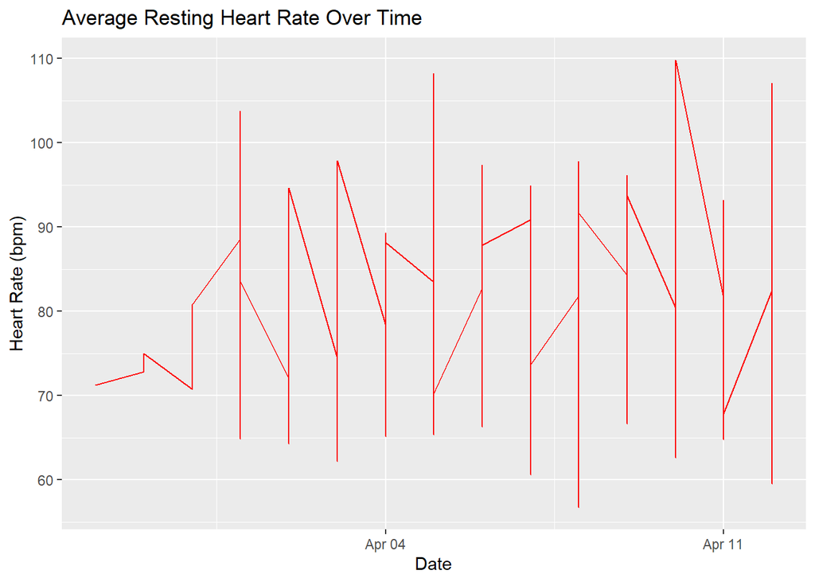

```r
# Heart rate by Day
hr_daily <- heartrate_df %>%
  mutate(Date = as_date(Time)) %>%
  group_by(Id, Date) %>%
  summarise(restHR = mean(Value), .groups = "drop")

ggplot(hr_daily, aes(x = Date, y = restHR)) +
  geom_line(color = "red") +
  labs(title = "Average Resting Heart Rate Over Time",
       x = "Date", y = "Heart Rate (bpm)")
```

## Summary of Findings

#### 2. Sleep Duration vs Calories Burned

- Weak negative correlation: longer sleep duration is slightly associated with lower calories burned.
- Suggests that highly active days may coincide with shorter sleep, or that sedentary users sleep longer but burn fewer calories.

## Connecting Insights to the Business Problem

#### 2. Application to Bellabeat Customers

- Bellabeat’s target audience (primarily women interested in wellness) can benefit from:
- Daily nudges to reduce sedentary time and encourage consistent activity.
- Sleep–activity balance insights (e.g., “On days you walk more, you sleep less — try winding down earlier”).
- Stress and recovery monitoring via resting HR trends.
- Weight management support with personalized feedback on fluctuations.

#### 3. Influence on Bellabeat Marketing Strategy

- Highlight holistic wellness: not just steps, but the interplay of sleep, stress, and activity.
- Promote personalization: “Bellabeat learns your rhythms — morning walker, evening exerciser, or weekend warrior.”
- Gamify engagement: challenges for consistent sleep + activity balance, not just step counts.
- Position as a lifestyle coach: emphasize stress reduction, recovery, and sustainable weight management rather than raw fitness metrics.